# Ein Schnellkurs in Python und Jupyter Notebook

Diese Kurzeinführung in Python orientiert sich an "Schnellkurs in Matlab" von Prof. Dr. Oliver Stein. Es sei vorweg darauf hingewiesen, dass dieser Kurs keine allgemeine Einführung in Python bietet. Hierzu empfiehlt sich zum Beispiel das Tutorial von [Codecademy](https://www.codecademy.com/learn/python) oder [Udacity](https://www.udacity.com/course/introduction-to-python--ud1110). In deutscher Sprache gibt es außerdem die Übersetzung des [offiziellen Python-Tutorials](https://py-tutorial-de.readthedocs.io/de/python-3.3/index.html) sowie diese sehr umfassende [Python-Einführung](http://www.python-kurs.eu/index.php).

Dieser Schnellkurs soll den Leser in die Lage versetzen, einfache numerische Berechnungen, Programme und Visualisierungen in Python zu erstellen. Einige Berechnungen wirken für den erfahrenen Matlab-Nutzer möglicherweise etwas umständlich. Dies resultiert daraus, dass Python im Gegensatz zu Matlab eine vollwertige Programmiersprache ist, deren Fokus nicht primär auf Matrixoperationen liegt. Dennoch bietet Python für unsere Anwendungen einen vollwertigen Ersatz für Matlab.

Dank gilt Maren Beck, Paul Kandora, Robert Mohr und Stefan Schwarze für die Durchsicht und Überarbeitung des Materials.

## Installation von Anaconda

Anaconda ist eine Python-Distribution, die auf wissenschaftliches Arbeiten und die Analyse von (großen) Datenmengen ausgelegt ist. Unter anderem enthält sie für unsere Anwendungen wichtige Pakete wie NumPy und SciPy, die somit nicht separat installiert werden müssen. Anaconda ist kostenlos und frei erhältlich. Hinter dem Projekt steht die Firma Continuum Analytics, die darüber hinaus zusätzlichen kommerziellen Support anbietet.

Jupyter Notebook ist eine kostenlose und frei erhältliche Web-Application, die das Erstellen und Teilen von Dokumenten (wie diesem) ermöglicht, die sowohl Code, als auch Gleichungen, Visualisierungen und beschreibenden Text enthalten. Praktischerweise ist Juptyer Notebook bereits in Anaconda enthalten.

"Schritt Null" besteht darin, einen modernen Browser (wie z.B. [Firefox](https://www.mozilla.org/de/firefox/new/) oder [Google Chrome](https://www.google.de/chrome/browser/desktop/)) herunterzuladen oder Safari unter MacOS). In diesem werden wir dann arbeiten, um die interaktiven Dokumente zu erstellen.

Anschließend ist die [Installation von Anaconda](https://www.anaconda.com/products/individual) erforderlich. Eine ausführliche Dokumentation ist auf der Website von Anaconda ebenfalls zu finden. Wir arbeiten mit Version 3.6. Sobald die Installation abgeschlossen ist, kann Jupyter Notebook aus der Kommandozeile über den Befehl

`jupyter notebook`

gestartet werden, wobei man auch zunächst über die Kommandozeile in das gewünschte Arbeitsverzeichnis navigieren kann, z.B. durch

`cd VorlesungOptimierung\EinfuehrungPython`

Es öffnet sich der Browser in dem Verzeichnis, aus welchem wir Jupyter Notebook gestartet haben. Jupyter Notebook läuft unter http://localhost:8888/ und unter dem Reiter

`New -> Python 3`

können wir nun ein neues interaktives Dokument erstellen. Dies zeigt der folgende Screenshot (bitte ignorieren Sie für den Moment die Zeilen `Image("....png")`, diese dient nur dem Einbinden des Screenshots in das Dokument).

[figure not shown]

```python
from IPython.display import Image
Image('UebersichtDokumentErstellen.PNG')
```

Es sollte sich ein Dokument öffnen, das in etwa so aussieht:

[figure not shown]

```python
Image('Benutzeroberflaeche.PNG')
```

Alle Operationen der graphischen Benutzeroberfläche können auch über shortcuts auf der Tastatur ausgeführt werden. Diese werden im Folgenden mit Klammern aufgeführt und können auch über `Help -> Keyboard Shortcuts` nachgelesen werden.

Über den Reiter `Insert -> Insert Cell Below` (b) wird eine neue Zelle (**unter** der aktuell ausgewählten) erstellt. Diese ist standardmäßig eine Kommandozeile, in die wir ausführbaren Code schreiben können und durch `In [ ]` gekennzeichnet. Um Code schreiben zu können, müssen wir in eine Zelle navigieren. Dies geschieht entweder durch Mausklick auf die entsprechende Zelle, oder durch die `Enter`-Taste (wobei wir bei mehreren Zellen zunächst mit den Pfeiltasten zur gewünschten Zelle navigieren müssen). Mit `Esc` können wir wieder aus einer Zelle herausnavigieren. Diesen Code können wir im Anschluss unter `Cell -> Run Cell` (Ctrl + Enter) ausführen, was zur Ausgabe `Out [ ]` führt. Wählen wir im Dropdown-Menü `Markdown`, so können wir Fließtext zu Erklärung mit HTML-Formatierung und sogar Latex-Code schreiben, wie zum Beispiel

$$\nabla f(x) \stackrel{!}{=} 0$$

(Mit einem Doppelklick in diese Zelle, kann man sich den Code zu diesem Text anschauen.)

```python
print('Hello world')
```

```
Hello world
```

Das obige Beispiel führt den Befehl `print('Hello world')` aus, wobei `In [3]` dafür steht, dass der Befehl als 3'te Anweisung ausgeführt wird. Das Programmieren in Zellen und die damit verbundenen Unterteilung in Blocks ist nützlich zur Strukturierung und zur Auswertung einzelner Teile von Programmen. Dass die Zahl vor der Kommandozeile von Bedeutung ist, veranschaulicht das nachfolgende Beispiel:

```python
a = 3
b = 7
```

```python
a = 2
c = 10
```

```python
print(a*b*c)
```

```
140
```

Für eine ausführlichere Erklärung zu Jupyter Notebook, sei auf [diese Dokumentation](http://jupyter-notebook-beginner-guide.readthedocs.io/en/latest/what_is_jupyter.html) verwiesen.

**Hinweis:** Am Ende eines Programmblocks kann auch ohne den `print` Befehl eine Ausgabe erzeugt werden. Es wird allerdings immer nur die letzte Zeile ausgegeben.

```python
'hello'
a*b*c
```

```
140
```

```python
print('hello')
print(a*b*c)
```

```
hello
140
```

## Jupyter Notebook schließen

Den Browser (oder das Browserfenster) zu schließen reicht nicht aus, um die Jupyter Notebook App zu schließen, sondern es muss die damit verbundene Eingabeaufforderung geschlossen werden.

Für eine ausführliche Erläuterung verweisen wir auf [dieser Seite](https://jupyter-notebook-beginner-guide.readthedocs.io/en/latest/execute.html).

# Rechenoperationen mit Python

Wer sich bereits mit Matlab auskennt, kann einen Blick auf die Seite [numpy for MATLAB users](https://numpy.org/doc/stable/user/numpy-for-matlab-users.html) werfen.

Für das Rechnen mit Vektoren und Matrizen verwenden wir das Paket [NumPy](http://www.numpy.org/). Um etwas Schreibaufwand zu sparen, wird dieses üblicherweise as `np` importiert.

```python
import numpy as np
```

## Operationen, elementare Funktionen, Konstanten

Die üblichen arithmetischen Operationen Addition, Subtraktion, Multiplikation, Division und Potenzieren besitzen die Python-Syntax `a+b`, `a-b`, `a*b`, `a/b` bzw. `a**b`. Für elementare Funktionen, wie die Exponentialfunktion nutzen wir das NumPy-Paket wie folgt.

```python
np.exp(1j*np.pi)
```

```
(-1+1.2246467991473532e-16j)
```

Hierbei bezeichnet der Buchstabe *e* in wissenschaftlicher Notation eine Skalierung um Zehnerpotenzen. `1j` bezeichnet die imaginäre Einheit, `np.exp` die Exponentialfunktion und `np.pi` die Konstante $ \pi $.

Weitere wichtige Konstanten sind die unendlich große Zahl `Inf` und der Ausdruck "Not-A-Number" `NaN`.

```python
np.NAN * 3
```

```
nan
```

```python
np.inf - 10000
```

```
inf
```

```python
np.inf - np.inf
```

```
nan
```

## Vektoren und Matrizen

### Darstellung

Vektoren und Matrizen lassen sich in Python als ein- bzw. zweidimensionale Felder verstehen, die mit `np.array()`zum NumPy-Datentyp gecastet werden, der uns nützliche Funktionalitäten liefert. So kann ein $n$-dimensionaler Vektor $a$ mit `np.array([a1, ... , an])`, und eine Matrix $$A = \begin{pmatrix} A_{1,1} & \dots & A_{1,n} \\ \vdots & \ddots & \vdots \\ A_{n,1} & \dots & A_{n,n} \end{pmatrix} $$ mit `A = np.array([[A11,..., A1n],...,[An1,..., Ann]])` erzeugt werden.

Ein Vektor $a$ lässt sich entsprechend darstellen als

```python
a = np.array([1,2,12])
print(a)
print(a.shape)
```

```
[ 1  2 12]
(3,)
```

und eine Matrix $A$ als

```python
A = np.array([[0,0,1],
              [1,0,0],
              [0,1,0]])
A.shape #Ausgabe der Dimension von A
```

```
(3, 3)
```

**Hinweis:** Der Vektor $a$ besitzt nur eine Dimension und fungiert daher sowohl als Zeilen, als auch als Spaltenvektor. Wir könnten $a$ theoretisch ebenfalls explizit als Zeilen- oder Spaltenvektoren erstellen, indem wir es, analog zu der Erstellung der Matrizen, als zweidimensionales Feld initialisieren. Da dies bei der Adressierung und der Visualisierung zu zusätzlichem Aufwand führt, verzichten wir im Folgenden jedoch auf die explizite Darstellung von Zeilen- und Spaltenvektoren. Machen Sie sich bitte dennoch bewusst, ob es sich in den von Ihnen verwendeten Operation um Zeilen- oder Spaltenvektoren handelt.

$(n,n)$-Einheitsmatrizen, $(n,m)$-Einsermatrizen und $(n,m)$-Null-Matrizen liefern die Kommandos `np.eye(n), np.ones([n,m]), np.zeros([n,m])`:

```python
print(np.eye(3))
print(np.ones([2,3]))
print(np.zeros([3,1]))
```

```
[[1. 0. 0.]
 [0. 1. 0.]
 [0. 0. 1.]]
[[1. 1. 1.]
 [1. 1. 1.]]
[[0.]
 [0.]
 [0.]]
```

Oft sind die Werte eines Vektors/ einer Matrix im Voraus nicht bekannt, die Dimension jedoch schon. Aus effizienzgründen ist es dann sinnvoll, zunächst eine "Platzhalter-Matrix" mit einem der oben aufgeführten Befehle zu erstellen.

Der Befehl `np.arange(l,u,s)` erstellt einen Vektor mit Einträgen aus dem halboffenen Intervall $[l,u)$, wobei die einzelnen Elemente einen festen Abstand von $s$ haben. Gibt man $s$ nicht explizit vor, so wird als Standardschrittweite der Wert $1$ angenommen.

```python
a = np.arange(0,10,2)
a
```

```
array([0, 2, 4, 6, 8])
```

Für Integer-Argumente stimmt diese Funktion mit der von Python bereitgestellten Funktion `range(l,u,s)` überein, liefert allerdings bereits den benötigten NumPy-Datentyp. Die Funktion `range(l,u,s)`, die eine Liste (und keinen numerischen Vektor) liefert, werden wir später für `For-Schleifen` verwenden.

Mit `linspace(l,u,n)` ist es möglich, Vektoren mit $n$ Einträgen aus dem Intervall $[l,u]$ zu erzeugen, einen gleichmäßigen Abstand besitzen.

```python
a = np.linspace(10,12,7)
print(a)
```

```
[10.         10.33333333 10.66666667 11.         11.33333333 11.66666667
 12.        ]
```

### Adressierung

Die folgenden Operationen zeigen, wie man auf Elemente, Zeilen, Spalten und Untermatrizen einer Matrix zugreifen kann. Wichtig: **Python fängt bei der Adressierung bei 0 an**. Auf das Element $i$ eines Vektors $b$ können wir über `b[i]` zugreifen. Hier zeigt sich, warum es ungünstig ist $b$ explizit als Zeilen- oder Spaltenvektor anzugeben, denn dann müsste ein Zugriff auf Index $i$ über `b[i,0]`, bzw. `b[0,i]` erfolgen. Das Element einer Matrix, das in Zeile $i$ und Spalte $j$ steht, adressieren wir über `B[i,j]`. Der Doppelpunkt signalisiert die Ausgabe von *allen* Elementen. Beispielsweise steht `B[1,:]` für die Ausgabe der *gesamten zweiten* Zeile der Matrix $B$ und `B[1,:10]` für die der ersten 10 Elemente (index 0 bis 9).

```python
B = np.array([[1,2,3,4],   #Zeile 0
              [5,6,7,8],   #Zeile 1
              [9,10,11,12]])  #Zeile 2
b = np.array([1,2,12])
```

```python
B[2,0]
```

```
9
```

```python
b[2]
```

```
12
```

```python
B[1,:]
```

```
array([5, 6, 7, 8])
```

Ein Minuszeichen als Index kennzeichnet das *Zählen von hinten*. Die letzte Zeile lässt sich also beispielsweise durch -1 adressieren:

```python
print(B[-1,:])
```

```
[ 9 10 11 12]
```

```python
print(B[0:-1,:])
```

```
[[1 2 3 4]
 [5 6 7 8]]
```

Bei einer Adressierung :-i werden die letzten i Zeilen **nicht** ausgegeben. Im vorigen Beispiel wird die Matrix B also ohne die letzte Zeile ausgegeben. Ebenso gibt die folgende Adressierung nur das erste Element von $b$ aus:

```python
print(b[0:1])
```

```
[1]
```

Außerdem können wir einzelne Zeilen (bzw. Spalten) definieren, an denen wir eine Matrix auswerten möchten

```python
indexSet = np.array([0,2])
print(B[indexSet,:])
print(B[:,indexSet])
```

```
[[ 1  2  3  4]
 [ 9 10 11 12]]
[[ 1  3]
 [ 5  7]
 [ 9 11]]
```

Eine wichtige Funktionalität ist das logische Adressieren. Möchte man beispielsweise nur alle Komponenten eines Vektors x für die dieser ungleich Null ist, so ist dies wie folgt möglich:

```python
x = np.array([0,1,0,2,2,3,0])
# print(x!=0)
print(x[x>=1])
```

```
[1 2 2 3]
```

`x!=0` liefert also einen logischen Vektor, der für jedes Element bestimmt, ob es ungleich Null ist. Somit wird `x` durch `x[x!=0]` dann nur denjenigen Stellen adressiert, an denen `x!=0` wahr ist.

### Weitere Anmerkungen

**Verschiedene Datentypen**:

Im Gegensatz zu Matlab können in Python Vektoren und Matrizen in verschiedenen Datentypen gespeichert werden. Das folgende Beispiel zeigt, dass dies zu unerwarteten Ergebnissen führen kann:

```python
a = np.array([1,1,1])
a[0] = a[0]/3
a[1] = a[1]/3
a[2] = a[2]/3
print(a.dtype)
print(a)
```

```
int32
[0 0 0]
```

Wird ein Vektor mit ganzzahligen Werten erzeugt, so wird dieser zunächst als Datentyp `int32` abgespeichert. Werden Elemente einzeln addressiert, so erwartet Python einen Wert vom Typ `int32`. Wie in obigem Beispiel gezeigt, können dadurch unerwartete Effekte auftreten!

Bei Operationen wie der Division auf dem ganzen Vektor wird dieser allerdings implizit zum Datentyp `float64` gecastet, sodass Gleitkommazahlen erlaubt sind und das wir das erwartete Ergebnis erhalten:

```python
a = np.array([1,1,1])
a = a/3
print(a)
print(a.dtype)
```

```
[0.33333333 0.33333333 0.33333333]
float64
```

Es empfiehlt sich, einen Vektor vom Datentyp `float64` folgendermaßen zu initialisieren:

```python
a = np.array([1.,1.,1.])
```

Werden Arrays und Matrizen mit Numpy-Funktionen wie `np.zeros()` oder `np.ones()` initialisiert, so haben diese den Datentyp `float64` und die obigen Probleme treten nicht auf.

**Außerdem wichtig:** Möchte man einen eigenständigen Vektor $y$ aus einem Vektor $x$ erzeugen, so ist die Funktion `y = np.copy(x)` zu verwenden. Andernfalls führt eine Änderung in $x$ auch zu einer Änderung in $y$, da $y$ auf $x$ referenziert, wie folgendes Beispiel verdeutlicht:

```python
x = np.array([1, 2, 3])
y = x
z = np.copy(x)
x[0] = 10
print(y)
print(z)
```

```
[10  2  3]
[1 2 3]
```

### Matrixoperationen

Wendet man in Python die Elementaroperationen $+, -, \times , \verb|\|$ auf Matrizen an, so resultiert dies stets in elementweisen Operationen. (In MATLAB wird eine elementweise Operationen mit einem zusätzlichen . vor dem Operator gekennzeichnet). Bei der Multiplikation von Vektoren und Matrizen müssen wir daher besonders Acht geben. So entspricht der Befehl `A * b` für eine $(n,n)$-Matrix $A$ und einen $n$-dimensionalen Vektor $b$ nicht dem Matrix-Vektorprodukt, sondern erzeugt eine Matrix $B$, deren Zeilen $i$ sich ergeben als $$B_i = [A_{i,1} * b_1, \dots, A_{i,n} * b_n].$$ Dies verdeutlicht folgendes Beispiel

```python
A = np.array([[0,0,1],
              [1,0,0],
              [0,1,0]])
b = np.array([1,2,3])
print('A*b ergibt: \n', A*b)
```

```
A*b ergibt:
 [[0 0 3]
 [1 0 0]
 [0 2 0]]
```

Um das Vektor-Matrix-Produkt $Ab$ zu bilden benutzen wir den @-Operator (möglich ab Python 3.5):

```python
A @ b
```

```
array([3, 1, 2])
```

Aufgrund der Tatsache, dass b sowohl als Zeilen, als auch als Spaltenvektor fungiert und $A$ quadratisch ist, ist die folgende Berechnung ebenso gültig:

```python
b @ A
```

```
array([2, 3, 1])
```

Machen Sie sich jedoch klar, dass $b$ im ersten Fall als Spalten- und im zweiten Fall als Zeilenvektor fungiert. Folglich lässt sich $b^\top b$ berechnen als

```python
b @ b
```

```
14
```

Möchte man das dyadische Produkt $b\cdot b^\top$ zweier Vektoren, so ist dies über die Methode `np.outer` möglich.

```python
np.outer(b,b)
```

```
array([[1, 2, 3],
       [2, 4, 6],
       [3, 6, 9]])
```

Addition, Subtraktion, Multiplikation, Division und Potenzieren zwischen einer Matrix und einem Skalar sind elementweise definiert:

```python
A = np.array([[0,0,1],
              [1,0,0],
              [0,1,0]])
b = np.array([1, 2, 3])
```

```python
b + 3
```

```
array([4, 5, 6])
```

```python
A - 5
```

```
array([[-5, -5, -4],
       [-4, -5, -5],
       [-5, -4, -5]])
```

```python
A*3
```

```
array([[0, 0, 3],
       [3, 0, 0],
       [0, 3, 0]])
```

```python
A**3
```

```
array([[0, 0, 1],
       [1, 0, 0],
       [0, 1, 0]], dtype=int32)
```

```python
A/2
```

```
array([[0. , 0. , 0.5],
       [0.5, 0. , 0. ],
       [0. , 0.5, 0. ]])
```

```python
(A/2)**2
```

```
array([[0.  , 0.  , 0.25],
       [0.25, 0.  , 0.  ],
       [0.  , 0.25, 0.  ]])
```

Auch die Verknüpfung zweier Matrizen $A, B$ mit * ist elementweise definiert, im Gegensatz zur Verknüpfung mit dem @-Operator, welcher das Produkt der beiden Matrizen liefert:

```python
A = np.array([[0,0,1],
              [1,0,0],
              [0,1,0]])
B = np.array([[1,2,3],
              [4,5,6],
              [7,8,9]])
print(A * B)
print(A @ B)
```

```
[[0 0 3]
 [4 0 0]
 [0 8 0]]
[[7 8 9]
 [1 2 3]
 [4 5 6]]
```

Die transponierte einer Matrix $A$ erhalten wir mit `A.transpose()` oder mit `A.T`:

```python
A = np.array([[1,2,3],[4,5,6],[7,8,9]])
print(A)
print(A.transpose())
print(A.T)
```

```
[[1 2 3]
 [4 5 6]
 [7 8 9]]
[[1 4 7]
 [2 5 8]
 [3 6 9]]
[[1 4 7]
 [2 5 8]
 [3 6 9]]
```

**Hinweis**: Wenn im Voraus klar ist, dass man in seinem Programm ausschließlich Matrix-Operationen verwenden möchte, kann man mit der Funktion `np.asmatrix(A)` festlegen, dass $A$ ein Matrix-Objekt ist. Dann ist die Operation `A * b` auch tatsächlich das Matrix-Vektor-Produkt. Die Numpy-Dokumentation empfiehlt allerdings aus [Gründen, die hier zusammengefasst sind](https://numpy.org/devdocs/user/numpy-for-matlab-users.html#array-or-matrix-which-should-i-use) die Nutzung von arrays.

Numpy's Paket zur linearen Algebra (`np.linalg`) stellt eine große Zahl von Standard-Matrixoperationen zur Verfügung, zum Beispiel zur Bestimmung der Determinanten, der Inversen oder von Eigenwerten und Eigenvektoren. Zur übersichtlichen Nutzung der von linalg bereitgestellten Funktionalitäten empfiehlt sich der statische Import:

```python
from numpy.linalg import *
```

```python
A = np.array([[1, 2, 3],
              [2, 4, 5],
              [3, 5, 6]])
```

So kann man beispielsweise für die Berechnung der Inversen anstatt

```python
B = np.linalg.inv(A)
print(B)
```

```
[[ 1. -3.  2.]
 [-3.  3. -1.]
 [ 2. -1.  0.]]
```

kurz schreiben:

```python
B = inv(A)
print(B)
```

```
[[ 1. -3.  2.]
 [-3.  3. -1.]
 [ 2. -1.  0.]]
```

**Hinweis:** Der Befehl `A.invert()` berechnet das bit-weise NOT der unterliegenden binären Representation der Integer-Werte der Matrix und hat dementsprechend wenig mit der von uns gesuchten Inversen zu tun.

$det(A) \cdot det(B)$ lässt sich entsprechend schreiben als

```python
det(A)*det(B)
```

```
0.999999999999998
```

Eigenwerte $e$ und Eigenvektoren $V$ werden bestimmt als

```python
e, V = eig(A)
print(e) # Eigenwerte
print(V) # Eigenvektoren
```

```
[11.34481428 -0.51572947  0.17091519]
[[-0.32798528 -0.73697623  0.59100905]
 [-0.59100905 -0.32798528 -0.73697623]
 [-0.73697623  0.59100905  0.32798528]]
```

Der Eigenvektor `V[:,i]`entspricht dabei dem Eigenwert `e[i]`.

## Funktionen

Funktionen werden mit dem Schlüsselwort `def` eingeleitet. Der Übergang zum Funktionsinhalt wird mit einem Doppelpunkt signalisiert

```python
def simpleBerechnung(a,b):
    result = a+2*b
    return result
```

```python
x = np.array([1,2,3])
y = np.array([8,0,1])
print(simpleBerechnung(x,7))
```

```
[15 16 17]
```

Dies verdeutlicht die Struktur der Python Programmierung. Sie verzichtet gänzlich auf geschweifte Klammern und Semikoli und benutzt Einrückungen als Kennzeichnung. Wir merken an, dass $a$ und $b$ als Input sowohl Skalare, Vektoren, als auch Matrizen sein können.

Besitzt eine Funktion mehrere Ausgabeargumente, so werden diese als Tupel übergeben.

```python
def simpleBerechnung2(a,b):
    result1 = a+2*b
    result2 = a-2*b
    return result1, result2
```

```python
simpleBerechnung2(x,y)
```

```
(array([17,  2,  5]), array([-15,   2,   1]))
```

### Lambda-Funktionen

Angenommen wir haben die folgende Funktion implementiert

```python
def simplePlus(func, x):
    return np.maximum(func(x), 0)
```

welche als Input-Argumente eine Funktion **func** und einen Vektor $x$ erwartet und als Output den Wert der Funktion **func** ausgewertet an $x$ liefert, sofern dieser Wert positiv ist, und ansonsten den Wert 0 zurückliefert. Nun haben wir drei Funktionen gegeben:

```python
def simpleFunc(x):
    return x**3 - 7

def linearFunc(x, a, b):
    return a * x + b

def quadFunc(x, c_1, c_2, c_3):
    return c_1 * x**2 + c_2 * x + c_3
```

Von diesen drei Funktionen können wir nur die Funktion **simpleFunc** an die Funktion **simplePlus** übergeben, weil nur diese Funktion die korrekte Aufrufstuktur besitzt (weil sie keine weiteren Parameter besitzt):

```python
x = np.array([-2.5, 0, 10])
print(simpleFunc(x))
print(simplePlus(simpleFunc, x))
```

```
[-22.625  -7.    993.   ]
[  0.   0. 993.]
```

Mit Hilfe von Lambda-Funktionen können wir jedoch die Aufrufstruktur der anderen beiden Funktionen so anpassen, dass auch sie an die Funktion **simplePlus** übergeben werden können:

```python
a = 3
b = 2
print(linearFunc(x, a, b))
func_1 = lambda x: linearFunc(x, a, b)
print(func_1(x))
print(simplePlus(func_1, x))
```

```
[-5.5  2.  32. ]
[-5.5  2.  32. ]
[ 0.  2. 32.]
```

```python
c_1 = 1
c_2 = 4
c_3 = -2
print(quadFunc(x, c_1, c_2, c_3))
func_2 = lambda x: quadFunc(x, c_1, c_2, c_3)
print(func_2(x))
print(simplePlus(func_2, x))
```

```
[ -5.75  -2.   138.  ]
[ -5.75  -2.   138.  ]
[  0.   0. 138.]
```

In dieser Veranstaltung werden wir häufig Funktionen (die von irgendwelchen Daten abhängen) an Optimierungsverfahren übergeben. Hier liefern uns die Lambda-Funktionen eine einfache Möglichkeit, die Aufrufstruktur der Funktion so anzupassen, dass sie an das Optimierungsvefahren übergeben werden kann.

## Vergleichsoperatoren und logische Operatoren

Die Vergleichsoperatoren $<, \leq, >, \geq, =$ und $\neq$ haben die Python-Syntax `<, <=, >, >=, ==` bzw. `!=`. Sie dienen dazu, zwei Matritzen elementweise zu vergleichen.

```python
A = np.array([[1, 2, 3],
              [0, 2, 1],
              [3, 5, 6]])
print(A>=3)
```

```
[[False False  True]
 [False False False]
 [ True  True  True]]
```

Für Vergleiche, ob alle (oder mindestens eines der) Elemente einer Matrix eine bestimmte Bedingung erfüllen, empfiehlt es sich, die von Numpy bereitgestellten Methoden `np.all(A)` und `np.any(A)` zu verwenden.

```python
print(np.all(A>=3))        # Überprüft, ob jedes Element der Matrix >=3 ist
print(np.all(A>=3,axis=1)) # Überprüft für jede Zeile, ob ein Element größer oder gleich 3 sind
```

```
False
[False False  True]
```

```python
print(np.any(A>=3))        # Überprüft, ob mindestens ein Element der Matrix >=3 ist
print(np.any(A>=3,axis=1)) # Überprüft für jede Zeile, ob mindestens ein Element größer oder gleich 3 sind
```

```
True
[ True False  True]
```

## Steuerstrukturen

Steuerstrukturen erlauben es, den Ablauf eines Programmes zu steuern. Python bietet verschiedene Möglichkeiten, den sequentiellen Ablauf durch Schleifen und Verzweigungen zu verändern. Von diesen werden wir im Folgenden kurz for- und while-Schleifen und if-Verzweigungen vorstellen.

### For-Schleifen

For-Schleifen iterieren in Python durch Listen. Nutzen wir beispielsweise die oben erwähnte `range`-Methode, so lässt sich eine Schleife schreiben als

```python
for i in range(0,3):
    print(i)
```

```
0
1
2
```

Dies ist praktisch, wenn wir beispielsweise iterativ Elemente einer Matrix adressieren möchten. In Python können wir allerdings ebenso durch beliebige Listen iterieren, wie folgendes Beispiel zeigt:

```python
farben = ['rot','gelb','blau']
for farbe in farben:
    print(farbe)
```

```
rot
gelb
blau
```

hier nimmt die Variable `farbe` iterativ die Werte der Liste `farben` an.

### While-Schleifen

Eine While-Schleife wiederholt eine Gruppe von Anweisungen so lange, bis ein Testausdruck falsch wird. Der folgende Code berechnet in der Variable s die Summe der ersten hundert natürlichen Zahlen:

```python
s = 0
k = 1
while k<=100:
    s = s + k
    k = k + 1
    # print(s)
print(s)
print(100*(100+1)/2)
```

```
5050
5050.0
```

### If-Verzweigungen

Eine If-Verzweigung wertet einen Testausdruck aus und lässt eine Gruppe von Anweisungen ausführen, wenn der Ausdruck wahr ist. Die Syntax wird im folgenden Beispiel verdeutlicht.

```python
def printGroesseX(x):
    if x<0:
        print('x ist zu klein')
    if x==0:
        print('x verschwindet')
    if x>0:
        print('x ist okay')
```

```python
printGroesseX(-3)
printGroesseX(3)
printGroesseX(0)
```

```
x ist zu klein
x ist okay
x verschwindet
```

## Visualisierung

Python verfügt über eine Vielzahl von leicht zu handhabenden Visualisierungsmoglichkeiten. Wir nutzen die [Matplotlib](https://matplotlib.org/), die dank Anaconda Distribution ebenso wie NumPy bereits vorinstalliert ist. Wir zeigen im Folgenden kurz, wie man die Matplotlib intuitiv nutzen kann. Da die Bibliothek sehr umfangreich ist, empfiehlt sich [diese Videoserie](https://www.youtube.com/playlist?list=PLQVvvaa0QuDfefDfXb9Yf0la1fPDKluPF) als ausführliche Einführung.

Um im Notebook einen interaktiven Graph zu erhalten, der sich beispielsweise auch als .pdf speichern lässt oder in dem wir zoomen können, nutzen wir den Befehl `%matplotlib` notebook. Der interaktive Modus bleibt erhalten, bis wir auf das "shutdown"-Symbol drücken.

```python
import matplotlib.pyplot as plt
```

```python
%matplotlib notebook
```

### Darstellung eindimensionaler Daten

Der plot-Befehl benötigt als Eingabe zwei Vektoren gleicher Länge, etwa $x$ und $y$.

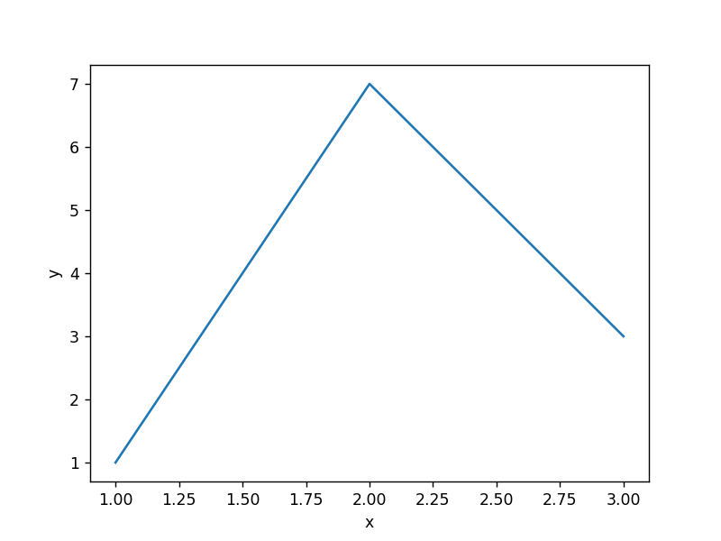

```python
x = np.array([1,2,3])
y = np.array([1,7,3])
plt.plot(x,y)
plt.ylabel('y')
plt.xlabel('x')
plt.show()
```

Achsen kann man mit `plt.xlabel(name)` und `plt.ylabel(name)` beschriften, einen Titel fügt das Kommando `plt.title(name)` hinzu, und ein Gitter wird mit `plt.grid()` eingeblendet. Der Funktion `plt.plot()` können weitere Argumente übergeben werden, die Farbe, Linienstil, ... verändern können. Eine Auflistung ist [hier](https://matplotlib.org/3.1.1/api/_as_gen/matplotlib.pyplot.plot.html?highlight=plot#matplotlib.pyplot.plot) zu finden. Mit `plt.legend()` kann eine Legende eingefügt werden.

Im nächsten Beispiel wollen wir die Funktionsgraphen der Funktion $x^3$ und $-x^3$ auf dem Intervall von -1 bis 1. plotten. Wir machen diese durch unterschiedliche Farben und eine Legende kenntlich.

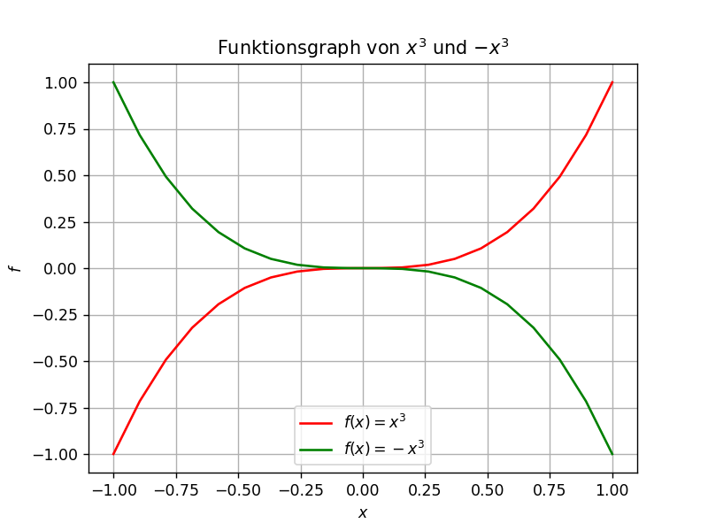

```python
x = np.linspace(-1,1,20)
p1 = plt.plot(x,x**3, color='red', label='$f(x)=x^3$')
p2 = plt.plot(x, -x**3, color='green', label='$f(x)=-x^3$')
plt.xlabel('$x$')
plt.ylabel('$f$')
plt.title('Funktionsgraph von $x^3$ und $-x^3$')
plt.legend(loc='lower center')
plt.grid()
plt.show()
```

[Hier](http://matplotlib.org/mpl_toolkits/mplot3d/tutorial.html#getting-started) findet sich eine Einführung für dreidimensionales Plotten mit der Matplotlib, das wir im Folgenden kurz vorstellen. Wir importieren die Pakete `axes3d` für die Dreidimensionalität und `cm` für die Färbung der Plots.

```python
from mpl_toolkits.mplot3d import axes3d
from matplotlib import cm
```

Der Befehl mesh stellt die Einträge einer $(m,n)$-Matrix Z als Funktionsgraph einer reell-wertigen Funktion von zwei Variablen dar. Als "diskretisierte Koordinatenachsen" gibt man einen Vektor *x* der Länge *n* und einen Vektor *y* der Länge *m* an:

```python
x = np.arange(1,5)
y = np.arange(1,4)
Z = np.arange(1,13).reshape([3,4])
print(Z)
```

```
[[ 1  2  3  4]
 [ 5  6  7  8]
 [ 9 10 11 12]]
```

```python
X,Y = np.meshgrid(x,y)
print(X)
print(Y)
```

```
[[1 2 3 4]
 [1 2 3 4]
 [1 2 3 4]]
[[1 1 1 1]
 [2 2 2 2]
 [3 3 3 3]]
```

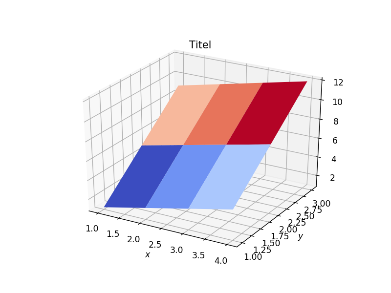

```python
fig = plt.figure()
ax = fig.add_subplot(111, projection='3d')
surf = ax.plot_surface(X, Y, Z, cmap=cm.coolwarm)
plt.title('Titel')
plt.xlabel('$x$')
plt.ylabel('$y$')
plt.show()
```

Die Färbung orientiert sich am Wert der Einträge von Z und kann mit der Option cmap geändert werden. Für weitere Optionen verweisen wir auf [diese Dokumentation](http://matplotlib.org/mpl_toolkits/mplot3d/tutorial.html#getting-started).

Als nächstes plotten wir die Funktion $f(x,y)=sin(cos(x\cdot y))$:

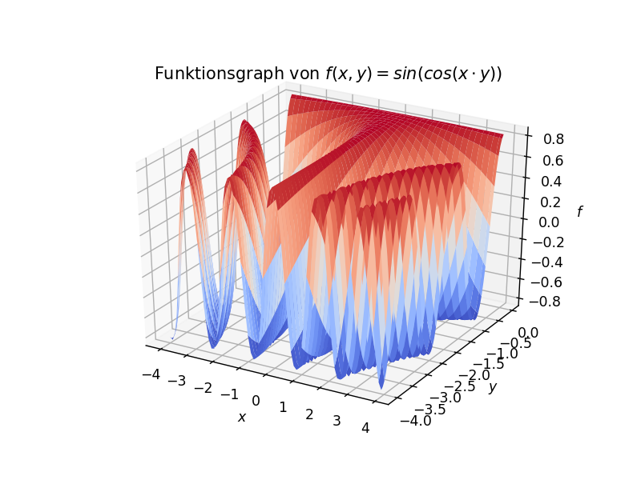

```python
X = np.arange(-4, 4, 0.1)
Y = np.arange(-4, 0, 0.05)
X, Y = np.meshgrid(X, Y)

fig = plt.figure()
ax = fig.add_subplot(111, projection='3d')
ax.set_xlabel('$x$')
ax.set_ylabel('$y$')
ax.set_zlabel('$f$')
ax.set_title('Funktionsgraph von $f(x,y)=sin(cos(x\cdot y))$')

Z = np.sin(np.cos(X*Y))

surf = ax.plot_surface(X, Y, Z, cmap=cm.coolwarm)
```

## Optimierung

### Dictionaries

Pythons Dictionary ist neben der Liste eine der meistgenutztesten Datenstrukturen in Python. Genau wie ein Wörterbuch entspricht ein Dictionary einer Abbildung von Schlüsseln (Keys) auf Werte.

Ein Dictionary wird durch geschweifte Klammern gekennzeichnet. Einzelne Elemente sind durch Kommata getrennt und die Zuweisung Key zu Wert erfolgt über einen Doppelpunkt.

```python
farben_de_en = {'rot':'red', 'blau':'blue', 'grün':'green'}
print(farben_de_en['rot'])
```

```
red
```

Wir verwenden Dictionary im Folgenden zur Übergabe von Optimierungsparametern an Solver. Für eine ausführlichere Einführung, verweisen wir auf [dieses Tutorial](https://www.tutorialspoint.com/python/python_dictionary.htm).

### Optimierung mit SciPy

`SciPy.optimize` ist ein frei zugängliches Paket, um allgemeine Optimierungsprobleme z.B. der Form

$$P: \min_{x \in \mathbb{R}^n}\;f(x) \qquad s.t. \quad g_i(x) \geq 0, \ i \in I, \quad h_j(x) = 0, \ j \in J$$

mit Standard-Algorithmen zu lösen. Ein ausführliche Einführung findet sich [hier](https://docs.scipy.org/doc/scipy/reference/tutorial/optimize.html). Wichtig ist es hier, dass die Funktionen $f$ und $g_i$ vektorisiert angegeben werden (d.h. dass die Funktionen nur von einem Vektor - hier dann ein `np.array` - abhängen).

```python
def f(x):
    result = (x[0]-3)**2 + x[1]**2
    return result
def g_1(x):
    result = np.array([-x[0] + x[1] -2])
    return result
def g_2(x):
    result = np.array([-x[0]**2 - x[1]**2 + 6])
    return result
```

Jede Constraint wird als Dictionary geschrieben, wobei der Schlüssel 'type' auf den Constraint-Typ und der Schlüssel 'fun' auf die Funktion abbildet. Die Dictionaries werden mit Kommata in Klammern zusammengefügt, was einem Tupel (einer unveränderlichen Liste) von Dictionaries entspricht.

```python
cons = ({'type' : 'ineq',
         'fun': g_1
        },
        { 'type': 'ineq',
          'fun': g_2})
```

Mit der Methode `minimize` aus dem `scipy.optimize` Paket, können wir verschiedene Optimierungsprobleme, z.B. das oben genannte restringierte Problem, (numerisch) lösen. Der Methode können wir vorgeben, welches numerische Verfahren verwendet werden soll. Geben wir wie hier im folgenden Beispiel kein numerisches Verfahren an, wird entweder das BFGS-, L-BFGS-B- oder SLSQP-Verfahren je nach gegebender Problemstruktur, verwendet. Eine ausführliche Dokumentation ist [hier](https://docs.scipy.org/doc/scipy/reference/generated/scipy.optimize.minimize.html) zu finden.

```python
from scipy.optimize import minimize
```

```python
x0 = np.array([0,2])
res = minimize(f, x0, constraints=cons, options={'disp': True})
```

```
Optimization terminated successfully.    (Exit mode 0)
            Current function value: 12.514718625761018
            Iterations: 4
            Function evaluations: 17
            Gradient evaluations: 4
```

```python
res.x
```

```
array([0.41421356, 2.41421356])
```

```python
res
```

```
     fun: 12.514718625761018
     jac: array([-5.17156863,  4.82843137])
 message: 'Optimization terminated successfully.'
    nfev: 17
     nit: 4
    njev: 4
  status: 0
 success: True
       x: array([0.41421356, 2.41421356])
```

### Modellieren mit Python und Gurobi

Gurobi ist ein kommerzieller Solver für unterschiedliche Optimierungsprobleme. Wir verwenden ihn für lineare und quadratische Optimierungsprobleme, aufgrund der [guten Performance](http://www.gurobi.com/pdfs/benchmarks.pdf) und seiner übersichtlichen und leicht verständlichen Modellierungsstruktur für Python.

Gurobi stellt eine [freie akademische Lizenz zur Verfügung](https://www.gurobi.com/downloads/end-user-license-agreement-academic/), für die man sich mit seiner KIT-Mail Adresse registrieren muss. Für Anaconda lässt sich Gurobi **nach dem Erwerb der Lizenz** [wie hier beschrieben](http://www.gurobi.com/downloads/get-anaconda) installieren (wobei Schritt 1 natürlich ausgelassen werden kann, da wir bereits Anaconda installiert haben). Um mit Gurobi vertraut zu werden, empfiehlt sich [dieses Tutorial](https://www.youtube.com/watch?v=aKsfqB-ONfk), wir zeigen im Folgenden nur ein kleines Minimalbeispiel zur Modellierung mit Gurobi.

Auf den Pool-Rechnern ist Gurobi bereits installiert, hier müssen Sie also keine Installation vornehmen.

```python
from gurobipy import *
```

Im Folgenden lösen wir das Problem $$P: \qquad \min_{(x)\in \mathbb{R}^3} x_3$$ s.t. $$x_1 + 7 \leq x_3 $$ $$x_2 - 4 \leq x_3$$ $$-x_2 + 4 \leq x_3$$ $$-x_1 - x_2 \leq x_3.$$ mit Gurobi.

```python
m = Model("Ex1a")

# Definition der Variablen
x_1 = m.addVar(vtype = GRB.CONTINUOUS, name = "x_1")
x_2 = m.addVar(vtype = GRB.CONTINUOUS, name = "x_2")
x_3 = m.addVar(vtype = GRB.CONTINUOUS, name = "x_3")
m.update()

# Zielfunktion
m.setObjective(x_3 , GRB.MINIMIZE)
m.update()

# Restriktionen
m.addConstr(x_1 + 7 <= x_3, "c_1")
m.addConstr(x_2 - 4 <= x_3 , "c_2")
m.addConstr(-x_2 + 4 <= x_3, "c_3")
m.addConstr(-x_1-x_2 <= x_3, "c_4")
m.update()
```

```
Academic license - for non-commercial use only - expires 2022-08-13
Using license file C:\Users\hg2412\gurobi.lic
```

```python
m.optimize()
```

```
Gurobi Optimizer version 9.1.2 build v9.1.2rc0 (win64)
Thread count: 4 physical cores, 8 logical processors, using up to 8 threads
Optimize a model with 4 rows, 3 columns and 9 nonzeros
Model fingerprint: 0xece8581b
Coefficient statistics:
  Matrix range     [1e+00, 1e+00]
  Objective range  [1e+00, 1e+00]
  Bounds range     [0e+00, 0e+00]
  RHS range        [4e+00, 7e+00]
Presolve removed 4 rows and 3 columns
Presolve time: 0.00s
Presolve: All rows and columns removed
Iteration    Objective       Primal Inf.    Dual Inf.      Time
       0    7.0000000e+00   0.000000e+00   0.000000e+00      0s

Solved in 0 iterations and 0.01 seconds
Optimal objective  7.000000000e+00
```

```python
'Optimalpunkt x={} mit Optimalwert {}'.format(m.x, m.ObjVal)
```

```
'Optimalpunkt x=[0.0, 0.0, 7.0] mit Optimalwert 7.0'
```

```python
m.printAttr('X')
```

```
    Variable            X
-------------------------
         x_3            7
```

### Modellierung eines Transportproblems mit Python und Gurobi

(Verwendet in der Vorlesung zur Parametrischen Optimierung)

Wir betrachten ein Transportproblem der folgenden Form (vgl. Beispiel 1.1.3, Skript Gemischt-Ganzzahlige Optimierung I):

$$IP: \min_{x \in \mathbb{R}^6} 250 x_{11} + 300 x_{12} + 80 x_{21} + 100 x_{22} + 400 x_{31} + 200 x_{32}$$

unter den Nebenbedingungen

$$ \begin{align} x_{11} + x_{12} && \leq 12, && \\ x_{21} + x_{22} && \leq 18, &&\\ x_{31} + x_{32} && \leq 20, &&\\ x_{11} + x_{21} + x_{31} && = 22, &&\\ x_{12} + x_{22} + x_{32} && = 28,&& \\ x_{ij} && \geq 0,&& i \in I := \{1,2,3\}, \qquad j \in J:=\{1,2\}. \end{align} $$

Wir werden dieses Problem mit (Python und) Gurobi modellieren, uns eine optimale Lösung ausgeben lassen und diese weiter untersuchen.

#### Modellierung der Variablen

```python
m = Model('Beispiel1.1')
I = 3 #Angebotsstandorte
J = 2 #Nachfragestandorte
x = np.empty((I, J), dtype=object)
# Erstelle I*J Variablen
for i in range(I):
    for j in range(J):
        x[i,j] = m.addVar(vtype=GRB.CONTINUOUS, lb = 0, name="x_%d%d" %(i+1,j+1))
m.update()
```

#### Modellierung der Nebenbedingungen

#### Angebot:

```python
m.addConstr(x[0,0]  + x[0,1] <= 12)
m.addConstr(x[1,0] + x[1,1] <= 18)
m.addConstr(x[2,0] + x[2,1] <= 20)
m.update()
```

#### Nachfrage:

```python
m.addConstr(x[0,0] + x[1,0] + x[2,0] == 22)
m.addConstr(x[0,1] + x[1,1] + x[2,1] == 28)
m.update()
```

#### Zielfunktion:

```python
obj_vector = np.array([250,300,80,100,400,200])
m.setObjective(quicksum(m.getVars()*obj_vector))
m.update()
```

#### Lösen des Problems und Ausgabe eines Optimalpunktes:

```python
m.optimize()
m.printAttr('X')
```

```
Gurobi Optimizer version 9.1.2 build v9.1.2rc0 (win64)
Thread count: 4 physical cores, 8 logical processors, using up to 8 threads
Optimize a model with 5 rows, 6 columns and 12 nonzeros
Model fingerprint: 0x5cd83610
Coefficient statistics:
  Matrix range     [1e+00, 1e+00]
  Objective range  [8e+01, 4e+02]
  Bounds range     [0e+00, 0e+00]
  RHS range        [1e+01, 3e+01]
Presolve time: 0.00s
Presolved: 5 rows, 6 columns, 12 nonzeros

Iteration    Objective       Primal Inf.    Dual Inf.      Time
       0    4.5600000e+03   3.200000e+01   0.000000e+00      0s
       2    8.6000000e+03   0.000000e+00   0.000000e+00      0s

Solved in 2 iterations and 0.01 seconds
Optimal objective  8.600000000e+03

    Variable            X
-------------------------
        x_11           12
        x_21           10
        x_22            8
        x_32           20
```

#### Neues Szenario

Ein beliebiger Betriebsstandort kann ausgebaut werden, um bis zu eine Einheit mehr zu produzieren. Fragestellung: Welcher Standort sollte ausgebaut werden?

Da das Problem niedrigdimensional ist, können wir manuell die Optimalwerte $v_i$ der drei Probleme $P_1$, $ P_2$ und $P_3$ vergleichen, wobei $P_i$ dem Problem entspricht, in dem die Angebotsmenge von Standort $i$ um 1 Einheiterhöht wird.

```python
m = Model('Beispiel1.1_var')
I = 3 #Angebotsstandorte
J = 2 #Nachfragestandorte
x = np.empty((I, J), dtype=object)
# Erstelle I*J Variablen
for i in range(I):
    for j in range(J):
        x[i,j] = m.addVar(vtype=GRB.CONTINUOUS, lb = 0, name="x_%d%d" %(i+1,j+1))
m.update()

m.addConstr(x[0,0]  + x[0,1] <= 12) # Erhöht auf 13 für P_1
m.addConstr(x[1,0] + x[1,1] <= 18) # Erhöht auf 19 für P_2
m.addConstr(x[2,0] + x[2,1] <= 21) # Erhöht auf 21 für P_3
m.addConstr(x[0,0] + x[1,0] + x[2,0] == 22)
m.addConstr(x[0,1] + x[1,1] + x[2,1] == 28)
obj_vector = np.array([250,300,80,100,400,200])
m.setObjective(quicksum(m.getVars()*obj_vector))
m.update()
m.optimize()
m.printAttr('X')
```

```
Gurobi Optimizer version 9.1.2 build v9.1.2rc0 (win64)
Thread count: 4 physical cores, 8 logical processors, using up to 8 threads
Optimize a model with 5 rows, 6 columns and 12 nonzeros
Model fingerprint: 0x330ba286
Coefficient statistics:
  Matrix range     [1e+00, 1e+00]
  Objective range  [8e+01, 4e+02]
  Bounds range     [0e+00, 0e+00]
  RHS range        [1e+01, 3e+01]
Presolve time: 0.01s
Presolved: 5 rows, 6 columns, 12 nonzeros

Iteration    Objective       Primal Inf.    Dual Inf.      Time
       0    4.5600000e+03   3.200000e+01   0.000000e+00      0s
       2    8.5300000e+03   0.000000e+00   0.000000e+00      0s

Solved in 2 iterations and 0.01 seconds
Optimal objective  8.530000000e+03

    Variable            X
-------------------------
        x_11           11
        x_21           11
        x_22            7
        x_32           21
```

Der Optimalwert des Ursprungsproblems ist $v_0 = 8600$ Die Optimalwerte von $P_i,i\in \{1,2,3\}$, lauten $v_1 = 8600, v_2 = 8430, v_3 = 8530$ **$\Rightarrow$ Es sollte Standort 2 ausgebaut werden** .

Außerdem sehen wir, dass der Ausbau von Standort 1 keine Kosten spart. Der der Ausbau des zweiten Standort hingegen verringert die Kosten um 170 und der des dritten Standorts verringert die Kosten um 70.

#### Alternative Herangehensweise: "Schattenpreise"

Eine Alternative bietet bei linearen Optimierungsproblemen ein Blick auf die Dualvariablen der Lösung:

```python
for i in range(0,3):
    print('Der Ausbau von Standort %i um eine Einheit verbessert den Zielfunktionswert um %i'%
          (i+1, m.getConstrs()[i].getAttr(GRB.attr.Pi)))
```

```
Der Ausbau von Standort 1 um eine Einheit verbessert den Zielfunktionswert um 0
Der Ausbau von Standort 2 um eine Einheit verbessert den Zielfunktionswert um -170
Der Ausbau von Standort 3 um eine Einheit verbessert den Zielfunktionswert um -70
```

Wir müssen also keine zusätzlichen Optimierungsprobleme lösen, sondern ein Blick auf die Dualvariablen ist ausreichend um zu entscheiden, welchen Standort wir ausbauen müssen. Im Rahmen der Vorlesung zur parametrischen Optimierung wird es unter Anderem darum gehen, warum und unter welchen Umständen solche Prognosen über Kenntnisse der Dualvariablen möglich sind.

## Konvertieren von Jupyter Notebook Dokumenten

Jupyter Notebook Dokumente lassen sich praktischerweise in andere Formate konvertieren. Insbesondere erlaubt dies, Dokumente mit Programmcode und Erklärung einer Gruppe zugänglich zu machen, die nicht über eine Anaconda-Distribution verfügt. [Hier](https://nbconvert.readthedocs.io/en/latest/usage.html) findet sich eine ausführliche Erklärung. Mit dem Kommando

`jupyter nbconvert NAME.ipynb`

können wir das Jupyter-Notebook in ein html-Dokument konvertieren.